# R Notebook

1 MVP Now we’ll go back to CI creation in the normal fashion. We’ll take the ames data from the CIs lab earlier today and regard it now as a sample, we won’t be drawing any smaller samples from within it. This is the usual situation in an analysis: you use all the data available to you!

Load the data again, clean_names(), and re-familiarise yourself with it

```r
library(tidyverse)
library(janitor)
library(infer)
```

```r
ames_resample <- read_csv("~/codeclan_work/codeclan_homework_DebbieL/week_06/day_03/data/ames.csv")
```

[output not shown]

```r
ames_clean <- clean_names(ames_resample)

ames_clean
```

| order | pid | ms_sub_class | ms_zoning | lot_frontage | lot_area | street | alley | lot_shape | land_contour | utilities | lot_config | land_slope | neighborhood | condition_1 | condition_2 | bldg_type | house_style | overall_qual | overall_cond | year_built | year_remod_add | roof_style | roof_matl | exterior_1st | exterior_2nd | mas_vnr_type | mas_vnr_area | exter_qual | exter_cond | … |
| --- | --- | --- | --- | --- | --- | --- | --- | --- | --- | --- | --- | --- | --- | --- | --- | --- | --- | --- | --- | --- | --- | --- | --- | --- | --- | --- | --- | --- | --- | --- |
| 1 | 526301100 | 20 | RL | 141 | 31770 | Pave | NA | IR1 | Lvl | AllPub | Corner | Gtl | NAmes | Norm | Norm | 1Fam | 1Story | 6 | 5 | 1960 | 1960 | Hip | CompShg | BrkFace | Plywood | Stone | 112 | TA | TA | … |
| 2 | 526350040 | 20 | RH | 80 | 11622 | Pave | NA | Reg | Lvl | AllPub | Inside | Gtl | NAmes | Feedr | Norm | 1Fam | 1Story | 5 | 6 | 1961 | 1961 | Gable | CompShg | VinylSd | VinylSd | None | 0 | TA | TA | … |
| 3 | 526351010 | 20 | RL | 81 | 14267 | Pave | NA | IR1 | Lvl | AllPub | Corner | Gtl | NAmes | Norm | Norm | 1Fam | 1Story | 6 | 6 | 1958 | 1958 | Hip | CompShg | Wd Sdng | Wd Sdng | BrkFace | 108 | TA | TA | … |
| 4 | 526353030 | 20 | RL | 93 | 11160 | Pave | NA | Reg | Lvl | AllPub | Corner | Gtl | NAmes | Norm | Norm | 1Fam | 1Story | 7 | 5 | 1968 | 1968 | Hip | CompShg | BrkFace | BrkFace | None | 0 | Gd | TA | … |
| 5 | 527105010 | 60 | RL | 74 | 13830 | Pave | NA | IR1 | Lvl | AllPub | Inside | Gtl | Gilbert | Norm | Norm | 1Fam | 2Story | 5 | 5 | 1997 | 1998 | Gable | CompShg | VinylSd | VinylSd | None | 0 | TA | TA | … |
| 6 | 527105030 | 60 | RL | 78 | 9978 | Pave | NA | IR1 | Lvl | AllPub | Inside | Gtl | Gilbert | Norm | Norm | 1Fam | 2Story | 6 | 6 | 1998 | 1998 | Gable | CompShg | VinylSd | VinylSd | BrkFace | 20 | TA | TA | … |
| 7 | 527127150 | 120 | RL | 41 | 4920 | Pave | NA | Reg | Lvl | AllPub | Inside | Gtl | StoneBr | Norm | Norm | TwnhsE | 1Story | 8 | 5 | 2001 | 2001 | Gable | CompShg | CemntBd | CmentBd | None | 0 | Gd | TA | … |
| 8 | 527145080 | 120 | RL | 43 | 5005 | Pave | NA | IR1 | HLS | AllPub | Inside | Gtl | StoneBr | Norm | Norm | TwnhsE | 1Story | 8 | 5 | 1992 | 1992 | Gable | CompShg | HdBoard | HdBoard | None | 0 | Gd | TA | … |
| 9 | 527146030 | 120 | RL | 39 | 5389 | Pave | NA | IR1 | Lvl | AllPub | Inside | Gtl | StoneBr | Norm | Norm | TwnhsE | 1Story | 8 | 5 | 1995 | 1996 | Gable | CompShg | CemntBd | CmentBd | None | 0 | Gd | TA | … |
| 10 | 527162130 | 60 | RL | 60 | 7500 | Pave | NA | Reg | Lvl | AllPub | Inside | Gtl | Gilbert | Norm | Norm | 1Fam | 2Story | 7 | 5 | 1999 | 1999 | Gable | CompShg | VinylSd | VinylSd | None | 0 | TA | TA | … |

[output cut: 990 more lines]

Investigate the distribution of lot_area. Is the distribution roughly normal? If not, what problems do you find?

```r
ames_clean_mean <- ames_clean %>%
  summarise(
    mean_lot_area = mean(lot_area))

ames_clean_mean
```

| mean_lot_area |
| --- |
| 10147.92 |

```r
NA
NA
```

other variablle of interest

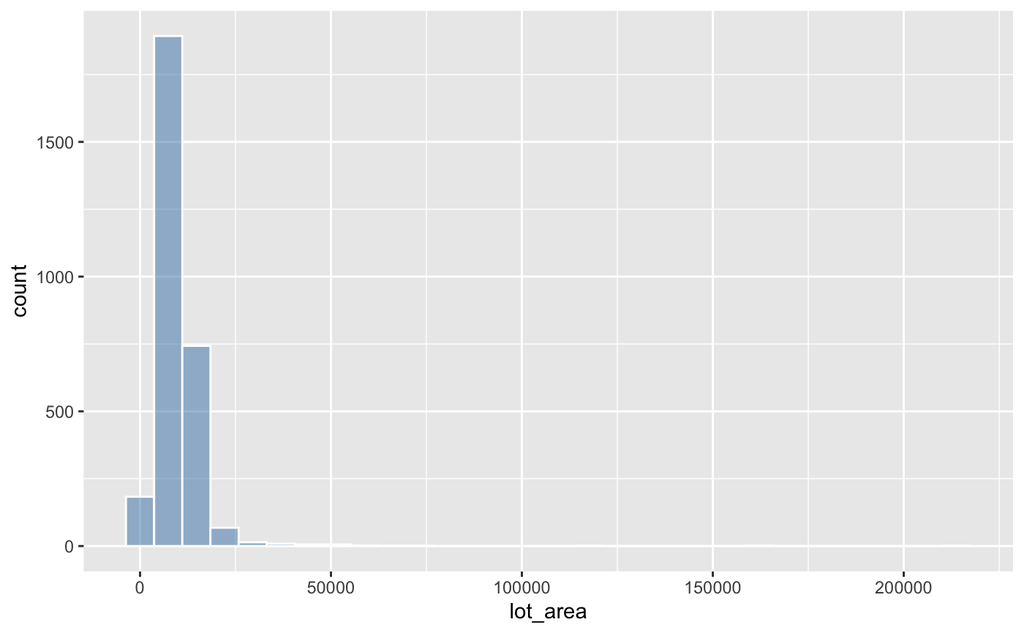

```r
ames_clean %>%
  ggplot(aes(x = lot_area)) +
  geom_histogram(col = "white", fill = "steel blue", alpha = 0.5)
```

Compute and visualise a bootstrap sampling distribution for the mean(lot_area) of the sold houses.

```r
bootstrap_resample_200 <- ames_clean %>%
                      rep_sample_n(size = 200, replace = TRUE, reps = 200) %>%
                      summarise(
                      mean_lot_area = mean(lot_area)
                      )
bootstrap_resample_200
```

| replicate | mean_lot_area |
| --- | --- |
| 1 | 9839.105 |
| 2 | 10412.175 |
| 3 | 10164.505 |
| 4 | 10018.995 |
| 5 | 9771.035 |
| 6 | 9534.160 |
| 7 | 10837.190 |
| 8 | 10318.430 |
| 9 | 10884.995 |
| 10 | 10099.835 |

[output cut: 190 more lines]

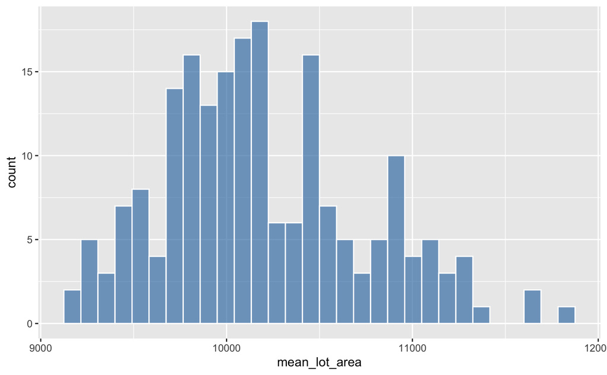

```r
bootstrap_resample_200 %>%
  ggplot(aes(x = mean_lot_area)) +
  geom_histogram(col = "white", fill = "steel blue", alpha = 0.7)
```

Solution- codeclan

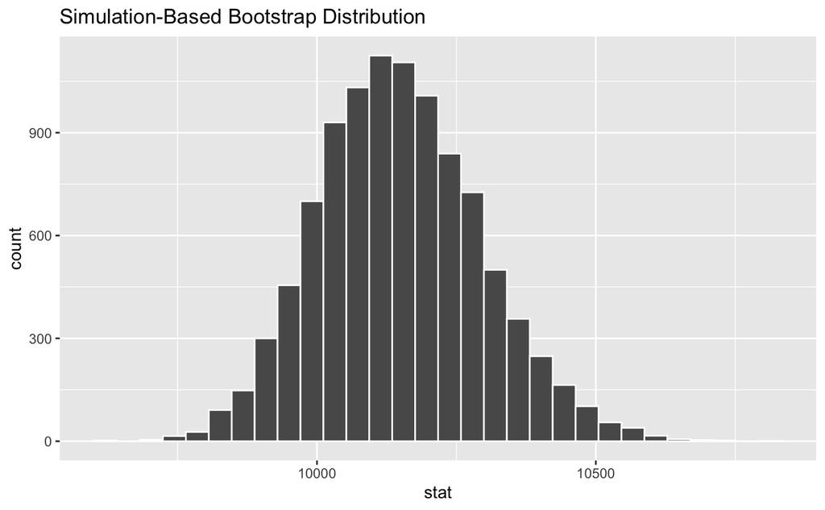

```r
bootstrap_distn <- ames_clean %>%
  specify(response = lot_area) %>%
  generate(reps = 10000, type = "bootstrap") %>%
  calculate(stat = "mean")

bootstrap_distn %>%
  visualise(bins = 30)
```

Use your bootstrap distribution to calculate a 95% CI for mean(lot_area), and visualise it on the distribution

```r
ci_95 <- bootstrap_resample_200 %>%
  summarise(
    mean = mean(mean_lot_area),
    lower_bound = quantile(mean_lot_area, probs = 0.025),
    upper_bound = quantile(mean_lot_area, probs = 0.975)
  )

ci_95
```

| mean | lower_bound | upper_bound |
| --- | --- | --- |
| 10188.03 | 9270.737 | 11292.28 |

```r
NA
```

Bootstrap distribution

```r
infer_resample <- ames_clean %>%
      specify(response = lot_area) %>%
      generate(reps = 200, type = "bootstrap") %>%
      calculate(stat = "mean")

infer_resample
```

| replicate | stat |
| --- | --- |
| 1 | 10295.394 |
| 2 | 10232.190 |
| 3 | 10505.146 |
| 4 | 10458.635 |
| 5 | 10267.903 |
| 6 | 10037.716 |
| 7 | 10361.739 |
| 8 | 10047.301 |
| 9 | 10203.729 |
| 10 | 10108.019 |

[output cut: 190 more lines]

```r
NA
```

```r
infer_resample_95 <- infer_resample %>%
        get_confidence_interval(level = 0.95, type = "percentile")

infer_resample_95
```

| lower_ci | upper_ci |
| --- | --- |
| 9868.423 | 10457.2 |

```r
NA
```

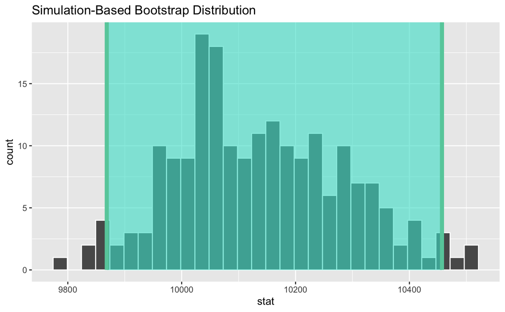

```r
infer_resample %>%
  visualise(bins = 30) +
  shade_confidence_interval(endpoints = infer_resample_95)
```

codeclan- solution

```r
lot_area_ci95 <- bootstrap_distn %>%
  get_ci(level = 0.95, type = "percentile")
lot_area_ci95
```

| lower_ci | upper_ci |
| --- | --- |
| 9879.377 | 10454.4 |

```r
NA
```

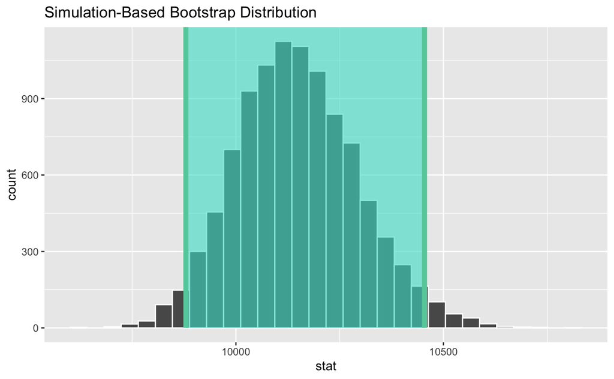

```r
bootstrap_distn %>%
  visualise(bins = 30) +
  shade_ci(endpoints = lot_area_ci95)
```

You would like to know the mean(lot_area) of the sold houses with higher confidence. Calculate the 99% CI for this variable (you can re-use your bootstrap distribution from above). Is it narrower or broader than the 95% CI? Does that make sense?

```r
ci_99 <- bootstrap_resample_200 %>%
  summarise(
    mean = mean(mean_lot_area),
    lower_bound = quantile(mean_lot_area, probs = 0.005),
    upper_bound = quantile(mean_lot_area, probs = 0.995)
  )

ci_99
```

[output not shown]

Calculate the point estimate of the mean(lot_area)

```r
infer_resample %>%
  summarise(mean(stat))
```

| mean(stat) |
| --- |
| 10138.78 |

```r
NA
```

codeclan solution

```r
lot_area_ci99 <- bootstrap_distn %>%
  get_ci(level = 0.99, type = "percentile")
lot_area_ci99
```

| lower_ci | upper_ci |
| --- | --- |
| 9809.014 | 10559.91 |

```r
NA
```

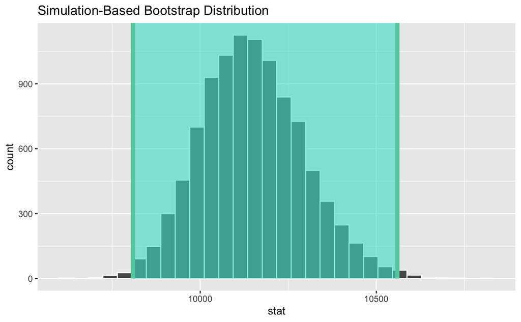

```r
bootstrap_distn %>%
  visualise(bins = 30) +
  shade_ci(endpoints = lot_area_ci99)
```

It is broader than the 95% CI. We haven’t increased sample size, so the only way to increase confidence is by increasing the width of the interval. Again, by analogy: to be more confident of catching the fish, you need to use a bigger net.

```r
ames_clean%>%
  summarise(point_est = mean(lot_area))
```

| point_est |
| --- |
| 10147.92 |

```r
bootstrap_distn %>%
  summarise(point_est = mean(stat))
```

| point_est |
| --- |
| 10148.31 |

```r
NA
```

2 Extension

Calculate a point estimate and 95% CI for the proportion of houses in the data built before 1920. Does the number of reps you use matter? [Investigate reps from 200 up to 50000, memory of your laptop permitting].

[Hint - the current implementation of calculate(stat = “prop”) in infer is slow! You can get around this by treating the mean in this way: add a new column via mutate(before_1920 = as.numeric(year_built < 1920)) and then calculate(stat = “mean”) on this new column]

```r
ames_built <- ames_clean %>%
      filter(year_built < 1920)

ames_built
```

| order | pid | ms_sub_class | ms_zoning | lot_frontage | lot_area | street | alley | lot_shape | land_contour | utilities | lot_config | land_slope | neighborhood | condition_1 | condition_2 | bldg_type | house_style | overall_qual | overall_cond | year_built | year_remod_add | roof_style | roof_matl | exterior_1st | exterior_2nd | mas_vnr_type | mas_vnr_area | exter_qual | exter_cond | … |
| --- | --- | --- | --- | --- | --- | --- | --- | --- | --- | --- | --- | --- | --- | --- | --- | --- | --- | --- | --- | --- | --- | --- | --- | --- | --- | --- | --- | --- | --- | --- |
| 170 | 902102100 | 50 | RM | 60 | 4800 | Pave | NA | Reg | Lvl | AllPub | Corner | Gtl | OldTown | Norm | Norm | 1Fam | 1.5Fin | 4 | 5 | 1900 | 1954 | Hip | CompShg | Wd Sdng | Wd Sdng | BrkFace | 771 | TA | TA | … |
| 171 | 902104060 | 50 | RM | 55 | 8800 | Pave | Grvl | Reg | Lvl | AllPub | Corner | Gtl | OldTown | Norm | Norm | 1Fam | 1.5Fin | 4 | 7 | 1910 | 2004 | Gable | CompShg | Wd Sdng | Wd Sdng | None | 0 | TA | TA | … |
| 175 | 902125080 | 50 | RM | 60 | 5790 | Pave | NA | Reg | Lvl | AllPub | Corner | Gtl | OldTown | Norm | Norm | 1Fam | 2Story | 3 | 6 | 1915 | 1950 | Gambrel | CompShg | VinylSd | VinylSd | None | 0 | Gd | Gd | … |
| 184 | 902305110 | 70 | RM | 60 | 9600 | Pave | Grvl | Reg | Lvl | AllPub | Corner | Gtl | OldTown | Norm | Norm | 1Fam | 2Story | 8 | 9 | 1900 | 2003 | Gable | CompShg | Wd Sdng | Wd Sdng | None | 0 | Gd | Gd | … |
| 185 | 902327040 | 50 | RM | 60 | 10800 | Pave | NA | Reg | Lvl | AllPub | Inside | Gtl | OldTown | Artery | Norm | 1Fam | 1.5Fin | 5 | 6 | 1915 | 1950 | Gable | CompShg | MetalSd | MetalSd | None | 0 | TA | Gd | … |
| 186 | 902329030 | 70 | RM | 50 | 9000 | Pave | Grvl | Reg | Lvl | AllPub | Inside | Gtl | OldTown | Norm | Norm | 1Fam | 2Story | 8 | 9 | 1890 | 2002 | Gable | CompShg | Wd Sdng | Wd Sdng | None | 0 | Gd | Gd | … |
| 187 | 902401060 | 190 | RM | 100 | 9045 | Pave | NA | Reg | Lvl | AllPub | Inside | Gtl | OldTown | Norm | Norm | 2fmCon | 2Story | 5 | 3 | 1910 | 1950 | Gable | CompShg | MetalSd | MetalSd | None | 0 | TA | Fa | … |
| 189 | 902402130 | 70 | RM | 60 | 7740 | Pave | NA | Reg | Lvl | AllPub | Inside | Gtl | OldTown | Norm | Norm | 1Fam | 2Story | 4 | 7 | 1910 | 1950 | Gable | CompShg | VinylSd | VinylSd | None | 0 | TA | TA | … |
| 190 | 902402250 | 190 | RM | 60 | 11340 | Pave | NA | Reg | Lvl | AllPub | Inside | Gtl | OldTown | Norm | Norm | 2fmCon | 2Story | 4 | 6 | 1885 | 1950 | Gable | CompShg | VinylSd | AsbShng | None | 0 | TA | TA | … |
| 203 | 903426180 | 50 | RM | 57 | 8094 | Pave | Grvl | Reg | Lvl | AllPub | Inside | Gtl | OldTown | Norm | Norm | 1Fam | 1.5Fin | 4 | 5 | 1915 | 1950 | Gable | CompShg | MetalSd | MetalSd | None | 0 | TA | Fa | … |

[output cut: 166 more lines]

```r
NA
```

```r
bootstrap_ames_built_176 <- ames_built %>%
    rep_sample_n(size = 176, replace = TRUE, reps = 176) %>%
    summarise(
      mean_year_built = mean(year_built)
    )
bootstrap_ames_built_176
```

| replicate | mean_year_built |
| --- | --- |
| 1 | 1907.131 |
| 2 | 1907.307 |
| 3 | 1907.216 |
| 4 | 1907.011 |
| 5 | 1906.864 |
| 6 | 1906.807 |
| 7 | 1905.545 |
| 8 | 1906.574 |
| 9 | 1907.335 |
| 10 | 1907.403 |

[output cut: 166 more lines]

```r
NA
```

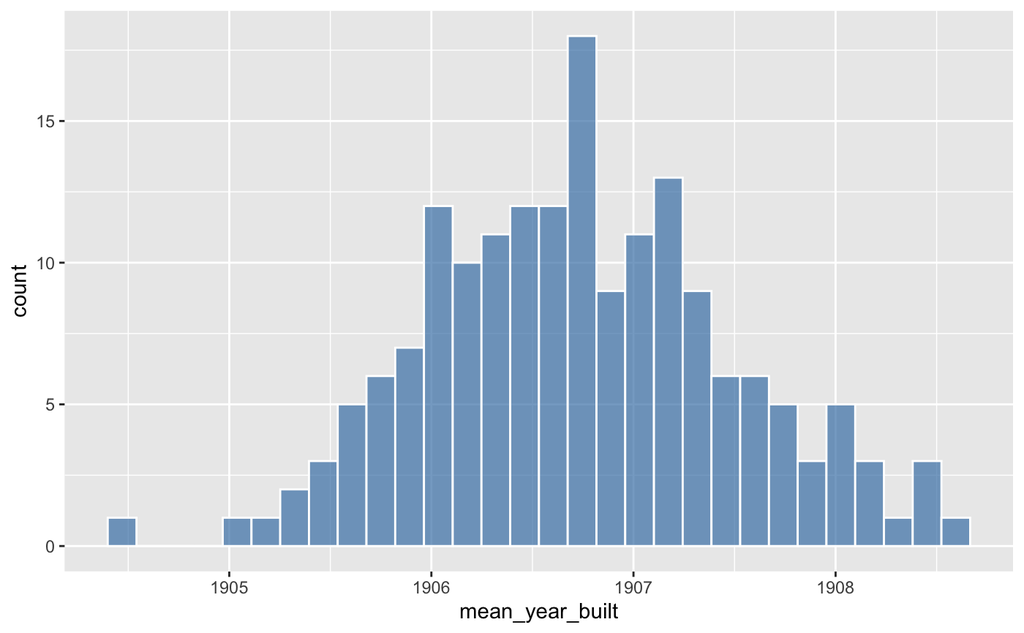

```r
bootstrap_ames_built_176 %>%
  ggplot(aes(x = mean_year_built)) +
  geom_histogram(col = "white", fill = "steel blue", alpha = 0.7)
```

```r
ames_ci_95 <- bootstrap_ames_built_176 %>%
  summarise(
    mean = mean(mean_year_built),
    lower_bound = quantile(mean_year_built, probs = 0.025),
    upper_bound = quantile(mean_year_built, probs = 0.975)
  )

ames_ci_95
```

| mean | lower_bound | upper_bound |
| --- | --- | --- |
| 1906.741 | 1905.376 | 1908.29 |

```r
NA
```

```r
infer_ames_built <- ames_built %>%
  specify(response = year_built) %>%
  generate(reps = 176, type = "bootstrap") %>%
  calculate(stat = "mean")

infer_ames_built
```

| replicate | stat |
| --- | --- |
| 1 | 1906.949 |
| 2 | 1908.568 |
| 3 | 1907.364 |
| 4 | 1906.761 |
| 5 | 1906.801 |
| 6 | 1907.000 |
| 7 | 1905.915 |
| 8 | 1907.938 |
| 9 | 1906.665 |
| 10 | 1906.602 |

[output cut: 166 more lines]

```r
NA
```

```r
infer_ci_95_ames <- infer_ames_built %>%
  get_confidence_interval(level = 0.95, type = "percentile")

infer_ci_95_ames
```

| lower_ci | upper_ci |
| --- | --- |
| 1905.492 | 1908.187 |

```r
NA
```

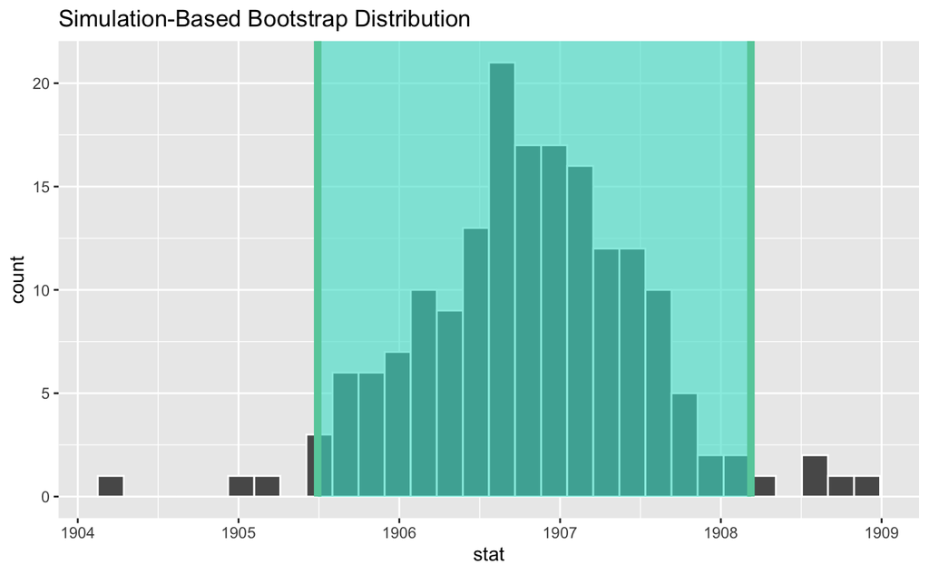

```r
infer_ames_built %>%
  visualise(bins = 30) +
  shade_confidence_interval(endpoints = infer_ci_95_ames)
```

```r
infer_ames_built %>%
  summarise(mean(stat))
```

| mean(stat) |
| --- |
| 1906.811 |

```r
NA
```

```r
ames_built_2 <- ames_built %>%
  mutate(before_1920 = as.numeric(year_built < 1920))

ames_built_2
```

[output not shown]

```r
bootstrap_ames_built2_176 <- ames_built_2 %>%
    rep_sample_n(size = 176, replace = TRUE, reps = 176) %>%
    summarise(
      mean_year_built = mean(before_1920)
    )


bootstrap_ames_built2_176
```

[output not shown]

codeclan solution

```r
ames_before_1920 <- ames_clean %>%
  mutate(before_1920 = as.numeric(year_built < 1920))
```

To investigate the effect of number of reps, let’s generate five different bootstrap sampling distributions

```r
bootstrap_distn_200 <- ames_before_1920 %>%
  specify(response = before_1920) %>%
  generate(reps = 200, type = "bootstrap") %>%
  calculate(stat = "mean")

bootstrap_distn_1000 <- ames_before_1920 %>%
  specify(response = before_1920) %>%
  generate(reps = 1000, type = "bootstrap") %>%
  calculate(stat = "mean")

bootstrap_distn_10000 <- ames_before_1920 %>%
  specify(response = before_1920) %>%
  generate(reps = 10000, type = "bootstrap") %>%
  calculate(stat = "mean")

bootstrap_distn_30000 <- ames_before_1920 %>%
  specify(response = before_1920) %>%
  generate(reps = 30000, type = "bootstrap") %>%
  calculate(stat = "mean")

bootstrap_distn_50000 <- ames_before_1920 %>%
  specify(response = before_1920) %>%
  generate(reps = 50000, type = "bootstrap") %>%
  calculate(stat = "mean")
```

Calculate point estimates:

```r
point_est <- ames_before_1920 %>%
  summarise(point_est = mean(before_1920))
point_est
```

| point_est |
| --- |
| 0.06006826 |

```r
NA
```

```r
point_est <- bootstrap_distn_50000 %>%
  summarise(point_est = mean(stat))
point_est
```

| point_est |
| --- |
| 0.06010378 |

```r
NA
```

Now calculate CI and visualise each distribution

```r
before_1920_ci95_200 <- bootstrap_distn_200 %>%
  get_ci(level = 0.95, type = "percentile")
before_1920_ci95_200
```

| lower_ci | upper_ci |
| --- | --- |
| 0.05221843 | 0.06860068 |

```r
NA
```

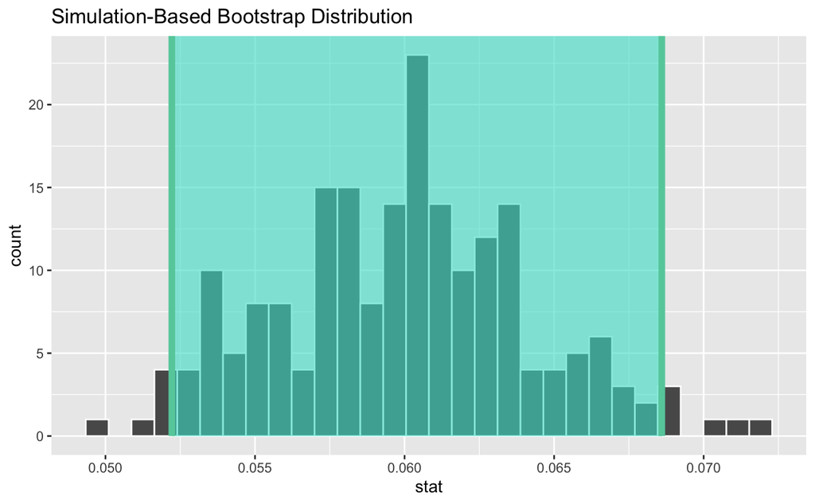

```r
bootstrap_distn_200 %>%
  visualise(bins = 30) +
  shade_ci(endpoints = before_1920_ci95_200)
```

```r
before_1920_ci95_1000 <- bootstrap_distn_1000 %>%
  get_ci(level = 0.95, type = "percentile")
before_1920_ci95_1000
```

| lower_ci | upper_ci |
| --- | --- |
| 0.05187713 | 0.06860068 |

```r
NA
```

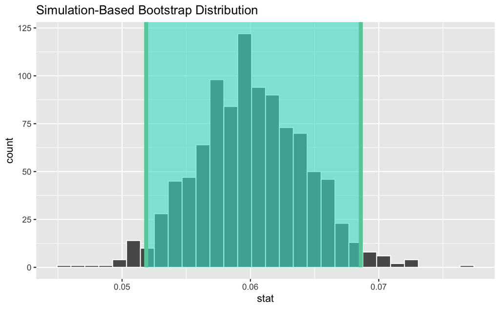

```r
bootstrap_distn_1000 %>%
  visualise(bins = 30) +
  shade_ci(endpoints = before_1920_ci95_1000)
```

```r
before_1920_ci95_10000 <- bootstrap_distn_10000 %>%
  get_ci(level = 0.95, type = "percentile")
before_1920_ci95_10000
```

| lower_ci | upper_ci |
| --- | --- |
| 0.05153584 | 0.06894198 |

```r
NA
```

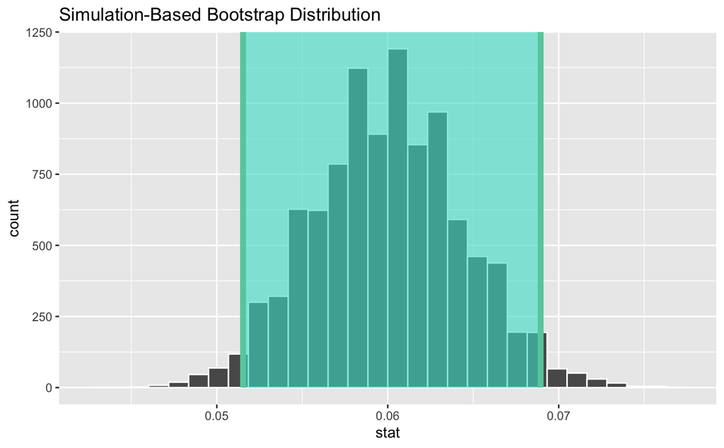

```r
bootstrap_distn_10000 %>%
  visualise(bins = 30) +
  shade_ci(endpoints = before_1920_ci95_10000)
```

```r
before_1920_ci95_30000 <- bootstrap_distn_30000 %>%
  get_ci(level = 0.95, type = "percentile")
before_1920_ci95_30000
```

| lower_ci | upper_ci |
| --- | --- |
| 0.05153584 | 0.06894198 |

```r
NA
```

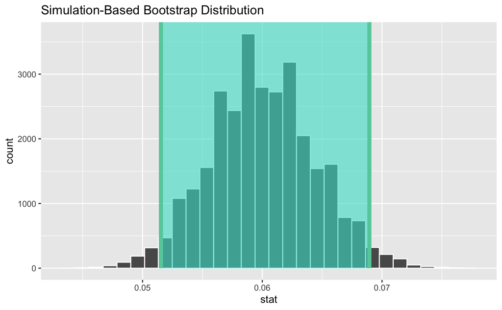

```r
bootstrap_distn_30000 %>%
  visualise(bins = 30) +
  shade_ci(endpoints = before_1920_ci95_30000)
```

```r
before_1920_ci95_50000 <- bootstrap_distn_50000 %>%
  get_ci(level = 0.95, type = "percentile")
before_1920_ci95_50000
```

| lower_ci | upper_ci |
| --- | --- |
| 0.05153584 | 0.06894198 |

```r
NA
```

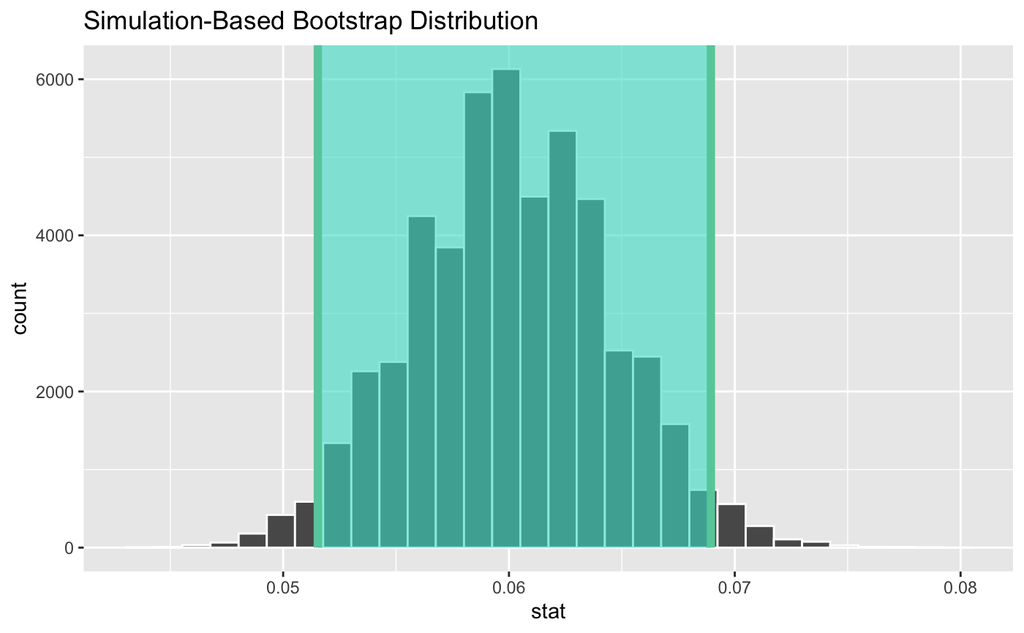

```r
bootstrap_distn_50000 %>%
  visualise(bins = 30) +
  shade_ci(endpoints = before_1920_ci95_50000)
```

CIs calculated using 10,000 bootstrap repetitions and upward seem more reliable than those using fewer resamplings. You should always test the sensitivity of your calculated CI to number of reps!